# HW04 Part 1: Complete Chapter 3

Melvin Cummings

26 December 2018

```r
library(tidyverse)
```

#### Plot <no.1>

Plot type: scatterplot Dataset: trees x-axis: height y-axis: girth

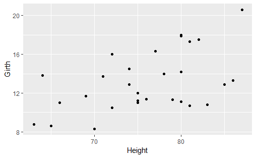

```r
data(trees)
?trees
ggplot(data = trees) + geom_point(mapping = aes(x=Height, y = Girth))
```

This plot shows a positive correlation between the girth and height of trees. #### Plot <no.2>

```r
?year
year <- c(1821:1934)
class(lynx)
```

```
[1] "ts"
```

```r
as.vector(year)
```

```
  [1] 1821 1822 1823 1824 1825 1826 1827 1828 1829 1830
 [11] 1831 1832 1833 1834 1835 1836 1837 1838 1839 1840
 [21] 1841 1842 1843 1844 1845 1846 1847 1848 1849 1850
 [31] 1851 1852 1853 1854 1855 1856 1857 1858 1859 1860
 [41] 1861 1862 1863 1864 1865 1866 1867 1868 1869 1870
 [51] 1871 1872 1873 1874 1875 1876 1877 1878 1879 1880
 [61] 1881 1882 1883 1884 1885 1886 1887 1888 1889 1890
 [71] 1891 1892 1893 1894 1895 1896 1897 1898 1899 1900
 [81] 1901 1902 1903 1904 1905 1906 1907 1908 1909 1910
 [91] 1911 1912 1913 1914 1915 1916 1917 1918 1919 1920
[101] 1921 1922 1923 1924 1925 1926 1927 1928 1929 1930
[111] 1931 1932 1933 1934
```

```r
pelts <- c(as.vector(lynx))
pelts
```

```
  [1]  269  321  585  871 1475 2821 3928 5943 4950 2577
 [11]  523   98  184  279  409 2285 2685 3409 1824  409
 [21]  151   45   68  213  546 1033 2129 2536  957  361
 [31]  377  225  360  731 1638 2725 2871 2119  684  299
 [41]  236  245  552 1623 3311 6721 4254  687  255  473
 [51]  358  784 1594 1676 2251 1426  756  299  201  229
 [61]  469  736 2042 2811 4431 2511  389   73   39   49
 [71]   59  188  377 1292 4031 3495  587  105  153  387
 [81]  758 1307 3465 6991 6313 3794 1836  345  382  808
 [91] 1388 2713 3800 3091 2985 3790  674   81   80  108
[101]  229  399 1132 2432 3574 2935 1537  529  485  662
[111] 1000 1590 2657 3396
```

```r
lynx_pelts <- data.frame(year, pelts)
lynx_pelts
```

| year | pelts |
| --- | --- |
| 1821 | 269 |
| 1822 | 321 |
| 1823 | 585 |
| 1824 | 871 |
| 1825 | 1475 |
| 1826 | 2821 |
| 1827 | 3928 |
| 1828 | 5943 |
| 1829 | 4950 |
| 1830 | 2577 |

[output cut: 104 more lines]

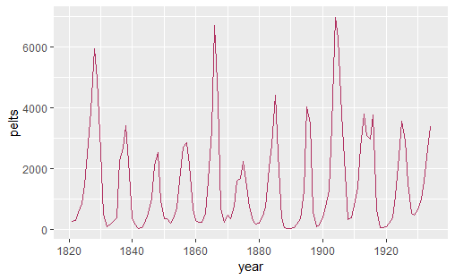

```r
ggplot(data = lynx_pelts, mapping = aes(x = year, y = pelts)) + geom_line(color = "maroon")
```

This plot shows the treadline and difference in years as pelts increases and decreases.

#### Plot <no.3>

Plot type: scatterplot Dataset: iris x-axis: petal length y-axis: petal width Point color and shape by species. You do not have to use fillable shapes. Point size of 2 Add a labs layer to change the x- and y-axis labels so that they do not have periods in the names (i.e., Petal Length, Petal Width).

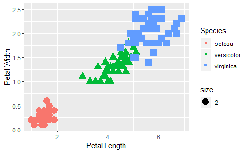

```r
data("iris")
?iris
ggplot(data = iris) + geom_point(mapping = aes(x = Petal.Length, y = Petal.Width, color = Species, shape = Species, size = 2)) + labs(x = "Petal Length") + labs(y = "Petal Width")
```

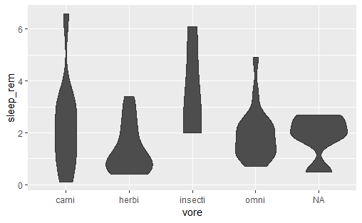

```r
data("msleep")
?msleep
ggplot(msleep) + geom_violin(mapping = aes(x = vore, y = sleep_rem), fill = "grey30")
```

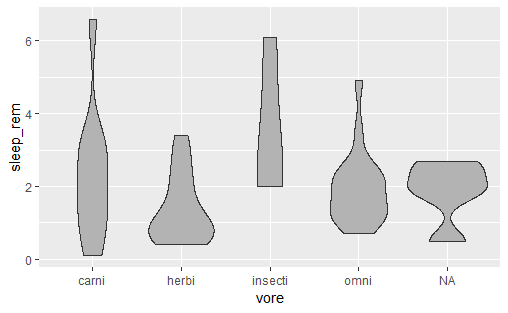

```r
data("msleep")
?msleep
ggplot(msleep) + geom_violin(mapping = aes(x = vore, y = sleep_rem), fill = "grey70")
```

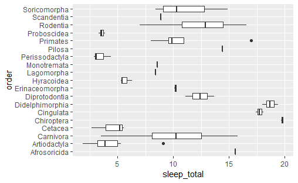

```r
data("msleep")
?msleep
ggplot(data = msleep) + geom_boxplot(mapping = aes(x = order, y = sleep_total)) + coord_flip()
```

This plot is a box plot which shows the order of mammals when compared to total sleep #### Plot <no.8> Plot type: boxplot with points • Dataset: msleep • x-axis: conservation • y-axis: awake 3 • You must have a boxplot layer, a point layer, and a jitter layer. • color by conservation status. • You may use coord_flip but it is not required. Try both and choose the one you think looks best. • Add a lab layer to change both axis labels so each starts with an upper-case letter. • Search the internet to find out how to change the legend title to Conservation. Make that change. (Do not try to change the actual legend entries like “cd” and “vu”). Note: This can be done a couple of different ways but scale_color_discrete() is one good way

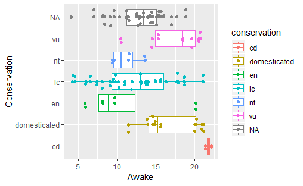

```r
data("msleep")
ggplot(data = msleep) + geom_boxplot(mapping = aes(x = conservation, y = awake, color = conservation)) + labs(x = "Conservation") + labs(y = "Awake") + geom_jitter(mapping = aes(x = conservation, y = awake, color = conservation)) + geom_point(mapping = aes(x = conservation, y = awake, color = conservation)) + coord_flip() + scale_fill_discrete(name = "Conservation")
```

This plot shows the time that the mammal is awake when compared to conservation. #### Plot <no.9> One should plot any one of the “sleep” or “awake” variables against body weight. The other should plot any one of the “sleep” or “awake” variables against brain weight. • In each plot, color the points by one of the nominal data categories. Use a different category for each plot. • Apply facet_wrap() to at least one of the plots using one of the nominal variables. You decide whether you use 2 or 3 columns. Hint: use one of the nominal variables with relatively few different types for wrapping. Explore: What happens if you use a nominal variable like genus, with lots of types? • You should try a few versions of each graph until you find combinations that you think show some clear trends.

• Describe the patterns or trends you see in each graph. If you use nominal the data ruins the graph by being to large

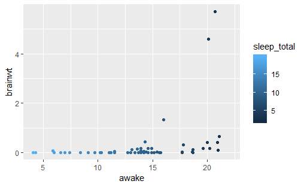

```r
ggplot(data = msleep) + geom_point(mapping = aes(x = awake, y = brainwt, color = sleep_total))
```

This plot shows the amount of mammal awake when compared to the brain weight. #### Plot <no.10>

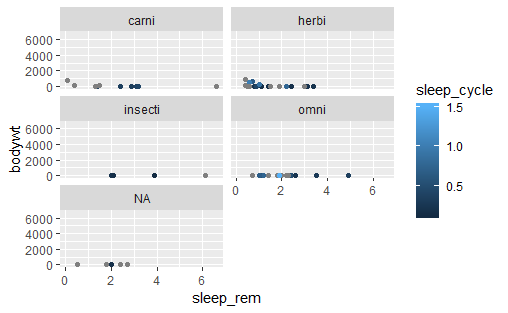

```r
ggplot(data = msleep) + geom_point(mapping = aes(x = sleep_rem, y = bodywt, color = sleep_cycle)) + facet_wrap(~ vore, ncol = 2)
```

These plots shows the difference of rem sleep when compared to body weight between the different mammal vore types.